# stroop_project

## Test a Perceptual Phenomenon

In, this project we have investigated a classic phenomenon from experimental psychology called the **Stroop Effect**.

### Introduction

In psychology, the *Stroop effect* is a demonstration of interference in the reaction time of a task. When the name of a color (e.g., "blue", "green", or "red") is printed in a color that is not denoted by the name (e.g., the word "red" printed in blue ink instead of red ink), naming the color of the word takes longer and is more prone to errors than when the color of the ink matches the name of the color. The effect is named after John Ridley Stroop, who first published the effect in English in 1935.**[1](https://en.wikipedia.org/wiki/Stroop_effect)**

### The Experiment

Participants are presented with a list of words, with each word displayed in a color of ink. The task requires the participants to read the written color names of the words independently of the color of the ink (for example, they would have to read "purple" no matter what the color of the font is). The word were of two types : **congruent** and **incongruent** words. In case of congruent words , the words match the colors in which they are printed and in case of incongruent words, the words displayed do not match the colors or ink in which they are printed. In each case, the time it takes a participant to name the ink colors in equally-sized lists is measured. Each participant will go through and record a time from each condition.**[5](http://rstudio-pubs-static.s3.amazonaws.com/255250_588c58f276104e28ba9899c45b2c5a57.html)** , **[1](https://en.wikipedia.org/wiki/Stroop_effect)**

### 1. Loading the Dataset

```python
#importing
import os
import pandas as pd
import numpy as np
# Reading the csv file and coverting to dataframe
df_stroop=pd.read_csv("stroopdata.csv")
df_stroop.head(25)
```

|  | Congruent | Incongruent |
| --- | --- | --- |
| 0 | 12.079 | 19.278 |
| 1 | 16.791 | 18.741 |
| 2 | 9.564 | 21.214 |
| 3 | 8.630 | 15.687 |
| 4 | 14.669 | 22.803 |
| 5 | 12.238 | 20.878 |
| 6 | 14.692 | 24.572 |
| 7 | 8.987 | 17.394 |
| 8 | 9.401 | 20.762 |
| 9 | 14.480 | 26.282 |
| 10 | 22.328 | 24.524 |
| 11 | 15.298 | 18.644 |
| 12 | 15.073 | 17.510 |
| 13 | 16.929 | 20.330 |
| 14 | 18.200 | 35.255 |
| 15 | 12.130 | 22.158 |
| 16 | 18.495 | 25.139 |
| 17 | 10.639 | 20.429 |
| 18 | 11.344 | 17.425 |
| 19 | 12.369 | 34.288 |
| 20 | 12.944 | 23.894 |
| 21 | 14.233 | 17.960 |
| 22 | 19.710 | 22.058 |
| 23 | 16.004 | 21.157 |

### Question 1: Identify variables in the experiment:

#### Question response correctly identifies the independent and dependent variables in the experiment.

Q1 . What is our independent variable? What is our dependent variable?

### Answer:

**Independent Variables** is the congruency (Congruent or Incongruent) which signifies whether the name of the color matches with the ink color.  
**Dependent Variables** is the time of response (in seconds)

### Question 2a & 2b: Establish hypotheses and Establish a statistical test:

#### Null and alternative hypotheses are clearly stated in words and mathematically. Symbols in the mathematical statement are defined. Also, A statistical test is proposed which will distinguish the proposed hypotheses. Any assumptions made by the statistical test are addressed.

Q2. What is an appropriate set of hypotheses for this task? What kind of statistical test do you expect to perform? Justify your choices.

### Answer :

1. μ<sub>i</sub> : population mean for incongruence words group
2. μ<sub>c</sub> : population mean for congruence words group

In this case,we are referring to the population means of congruence words group and incongruence words group - average times for the respective groups to recognize the colors. By comparing these means directly, we’ll be able to tell whether there is a difference between the two groups or not . However, it wouldn’t be possible to do the experiment with all potential subjects in the world, so we need to work with the sample we have on hand to make inference about the population means, i.e., to use the observation means, sd and other statistics to infer about the population means. In this case, the observation is the difference between the two groups’ times. With this new data, we can construct new statistics such as means and standard errors.**[6](https://rstudio-pubs-static.s3.amazonaws.com/118060_fcdc77aa7ffb452bb4cc8b67021d973a.html)**

**Null Hypothesis(Ho):** ( μ<sub>i</sub> - μ<sub>c</sub> = 0 ) There is no significant difference in the population average response times for the congruent(c) words vs the incongruent(i) words.

**Alternative Hypothesis(Ha):** ( μ<sub>i</sub> - μ<sub>c</sub> ≠ 0 ) There is a significant difference (positive or negative), in the population average response times.

**Statistical Test** : The **Dependent t-Test** would be the most appropriate statistical test to perform here. The samples are **Dependent** as the same subjects are assigned to two different conditions and the values in one sample affect the values in the other sample. In addition, we don't have any population parameters provided (so a z-test would not be appropriate here).

### Question 3: Report descriptive statistics:

#### Descriptive statistics, including at least one measure of centrality and one measure of variability,have been computed for the dataset’s groups.

Q3. Report some descriptive statistics regarding this dataset. Include at least one measure of central tendency and at least one measure of variability.

### Calculating the mean of the sample

```python
#directly we can find the mean using pandas
print(round(df_stroop.mean(),3))

#selecting individual column and finding mean

congruent = df_stroop['Congruent']
incongruent = df_stroop['Incongruent']
```

```
Congruent      14.051
Incongruent    22.016
dtype: float64
```

### Calculating the median of the sample

```python
#directly we can find the median using pandas
print(round(df_stroop.median(),3))
```

```
Congruent      14.356
Incongruent    21.018
dtype: float64
```

### Calculating Standard Deviation of the sample

```python
#directly we can find the median using pandas
print(round(df_stroop.std(),3))
```

```
Congruent      3.559
Incongruent    4.797
dtype: float64
```

**Standard deviation** is a number used to tell how measurements for a group are spread out from the average (mean), or expected value. A low standard deviation means that most of the numbers are very close to the average. A high standard deviation means that the numbers are spread out.**[2](https://simple.wikipedia.org/wiki/Standard_deviation)** . So here we can say that for our data our data is more spread out as our SD is high.

#### Outliers

In statistics, an **outlier** is an observation point that is distant from other observations.Outliers can occur by chance in any distribution, but they often indicate either measurement error or that the population has a heavy-tailed distribution. In the former case one wishes to discard them or use statistics that are robust to outliers, while in the latter case they indicate that the distribution has high skewness and that one should be very cautious in using tools or intuitions that assume a normal distribution. **[3](https://en.wikipedia.org/wiki/Outlier)**  
**Outliers < Q1−1.5×(IQR) or Outliers > Q3+1.5×(IQR)**

Thus below code will find out outliers in a list form for both the congruencies

**Congruent**

```python
# Calculating Q1 and Q2 for Congruent data
# below code gives 75th and 25th percentile
congruent_iqr75, congruent_iqr25 = np.percentile(congruent, [75 ,25])

round(congruent_iqr75,3)
round(congruent_iqr25,3)


# Calculating IQR for Congruent data
congruent_IQR = congruent_iqr75-congruent_iqr25
round(congruent_IQR,3)

print("Congruent :")

# Printing various values for
print('Q1 = ',congruent_iqr25,', Q3 = ',congruent_iqr75, ', IQR = ',congruent_IQR)

#cheking is there any outlier present?
cong_lower = (congruent_iqr25 - (1.5*congruent_IQR))
cong_upper = (congruent_iqr75 + (1.5*congruent_IQR))

# making a list for all congurent outliers
congruent_outliers =[]

# checking for outliers
for i in df_stroop['Congruent']:
    if (cong_lower > i or cong_upper < i):
        congrent_outliers.append(i)
    else:
        pass

# Printing list of Outliers
if len(congruent_outliers) == 0:
    print ('\n There is no outlier in the congruent sample')
else:
    print ('\nOutliers :',congrent_outliers)
```

```
Congruent :
Q1 =  11.89525 , Q3 =  16.20075 , IQR =  4.3055

 There is no outlier in the congruent sample
```

**Incongruent**

```python
incongruent_iqr75,incongruent_iqr25 = np.percentile(incongruent,[75,25])

round(incongruent_iqr75,3)
round(incongruent_iqr25,3)

# Calculating IQR for Incongruent data
incongruent_IQR = incongruent_iqr75 - incongruent_iqr25
round(incongruent_IQR,3)

print("Incongruent :")

# Printing various values for
print('Q1 = ',incongruent_iqr25,', Q3 = ',incongruent_iqr75, ', IQR = ',incongruent_IQR)

# Calulating range for checking the presence of outliers
incong_lower = (incongruent_iqr25-(1.5*incongruent_IQR))
incong_upper = (incongruent_iqr75+(1.5*incongruent_IQR))

# making a list for all congurent outliers
incongruent_outliers =[]

#checking for outliers

for i in df_stroop['Incongruent']:
    if (incong_lower > i or incong_upper < i):
        incongruent_outliers.append(i)
    else:
        pass

#printing list of outliers
if len(incongruent_outliers) == 0:
    print ('\nNo Outliers found for Incongruent data.')
else:
    print ('\nOutliers :',incongruent_outliers)
```

```
Incongruent :
Q1 =  18.71675 , Q3 =  24.0515 , IQR =  5.33475

Outliers : [35.255000000000003, 34.288000000000004]
```

**We can see that congruent data does not have any outliers but incongruent data has two.**

### Question 4: Plot the data:

#### One or two visualizations have been created that show off the data, including comments on what can be observed in the plot or plots.

Q4. Provide one or two visualizations that show the distribution of the sample data. Write one or two sentences noting what you observe about the plot or plots.

**1. Boxplot**

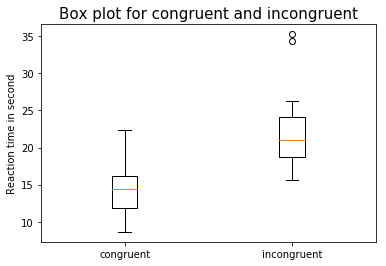

```python
import numpy as np
import matplotlib.pyplot as plt
%matplotlib inline
data = [congruent,incongruent]
plt.boxplot(data)

# Add x-axis
plt.xticks(range(1, 3), ('congruent', 'incongruent'))
# Add y-axis
plt.ylabel('Reaction time in second')
plt.title('Box plot for congruent and incongruent',fontsize = 15)
plt.show()
#plt.savefig("boxplotforboth.png",transparent = True)
```

From the above boxplot it is clearly visible that because of few outliers in incongruent sample the mean response time is increased.

**2. Histogram**

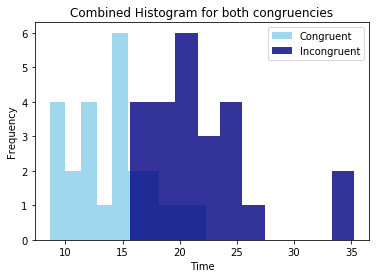

```python
plt.figure()
plt.hist(df_stroop['Congruent'],label = 'Congruent',alpha=0.8,color="skyblue")
plt.hist(df_stroop['Incongruent'],label = 'Incongruent',alpha=0.8,color='navy')
plt.legend()
plt.xlabel('Time')
plt.ylabel('Frequency')
plt.title('Combined Histogram for both congruencies')
plt.show()
```

### Question 5: Perform the statistical test and interpret your results:

#### A statistical test has been correctly performed and reported, including test statistic, p-value, and test result. The test results are interpreted in terms of the experimental task performed.

Q5. Now, perform the statistical test and report your results. What is your confidence level and your critical statistic value? Do you reject the null hypothesis or fail to reject it? Come to a conclusion in terms of the experiment task. Did the results match up with your expectations?

For performing statistical test , I am considering the below conditions:  
**Alpha(α)**: 0.05  
**Confidence Level** = 95%  
**t-critical value** (2-tailed test): **t<sub>critical</sub>** = +- 2.069 (From [t-table](https://s3.amazonaws.com/udacity-hosted-downloads/t-table.jpg) )  
**df** = n - 1 = 23  
**Below are calculating various parameters.**

```python
# Degrees of Freedom of the sample
degree_freedom = len(df_stroop)-1
print("Degree of Freedom:",degree_freedom)

# calculating t_critical value
from scipy import stats
t_critical = stats.t.ppf(1-0.025, degree_freedom)
print("T critical:",t_critical)

# point estimate of μi - μc -> Point_Estimate (in seconds)
congruent_mean =congruent.mean()
incongruent_mean = incongruent.mean()
point_estimate = congruent_mean - incongruent_mean
print("Point Estimate:",round(point_estimate,3))
```

```
Degree of Freedom: 23
T critical: 2.06865761042
Point Estimate: -7.965
```

```python
#1. diff = sample difference
df_stroop['diff'] = df_stroop['Incongruent'] - df_stroop['Congruent']

#2. DM stands for difference of the mean
# SD stands for squared differences of the mean
Mean_Diff = df_stroop['diff'].mean()
DM = df_stroop['diff'] - Mean_Diff
df_stroop['SD'] = DM*DM

#3. SSD = sum of squared differences
SSD = df_stroop['SD'].sum()

#4. variance = SSD/(degree_freedom)
variance = SSD/(degree_freedom)

# Standard_dev = sample standard deviation of differences
#5. Standard_dev = sqrt(variance)
from math import *
standard_dev = sqrt(variance)
standard_dev
round(standard_dev,3)
```

```
4.865
```

```python
# t_statistic Calculation
# As we have already calculated above, point_estimate = (μi - μc)
#t = Point_Estimate/(Standard_dev/√degree_freedom)
#t = (congruentMean - IncongruentMean)/(differenceSD/(math.sqrt(number_of_samples)))
standard_error = standard_dev/sqrt(degree_freedom+1)
t_statistics = point_estimate/(standard_error)
round(t_statistics,3)
```

```
-8.021
```

```python
# cohen's d Calulation
cohens_d = point_estimate / standard_dev

print(round(cohens_d,3))
```

```
-1.637
```

```python
#95% Confidence Interval
#CI = Confidence Interval
CI = []
# calculating upper and lower limits
ci_upper = point_estimate+(t_critical*standard_error)
ci_lower = point_estimate-(t_critical*standard_error)

#appending to the CI List
CI.append(ci_lower)
CI.append(ci_upper)

# printing CI
CI
```

```
[-10.019027909364908, -5.9105554239684208]
```

```python
# r squared value calculation

t_squared = t_statistics*t_statistics
r_param = (t_squared/(t_squared+degree_freedom))
r_param
```

```
0.7366364161445059
```

### Conclusion:

Here we observe that |t<sub>statistic</sub>| > |t<sub>critical</sub> or t<sub>α=0.05</sub>| i.e 8.021 > 2.0689

Thus we **reject** the Null Hypothesis stating that there is no significant differences between the population average completion time for the two different conditions (Congruent & Incongruent) or The real difference between group population means is zero. In theory, if we were able to calculate the average difference of every single person person who took this pair of tests (the population) we expect there would be a significantly slower or significantly faster time in either the the incongruent or congruent condition. Also, we get **r<sup>2</sup>** as *73.663%* which is approx. equal to *74%*, which means that *74%* of the variation of the time in the incongruent score from the congruent score is actually because the words were changed to incongruent.**[4](https://mayukhsobo.github.io/stroop_effect/hypothesis.html)**

#### References

[1] : **Stroop Effect** - https://en.wikipedia.org/wiki/Stroop_effect  
[2] : **Standard Deviation** - https://simple.wikipedia.org/wiki/Standard_deviation  
[3] : **Outlier** - https://en.wikipedia.org/wiki/Outlier  
[4] : **Stroop effect Testing** - https://mayukhsobo.github.io/stroop_effect/hypothesis.html  
[5] : **A Test of the Stroop Effect-Zexin Xia** - http://rstudio-pubs-static.s3.amazonaws.com/255250_588c58f276104e28ba9899c45b2c5a57.html  
[6] : **Test a Perceptual Phenomenon - Stroop Effect by George Liu** - https://rstudio-pubs-static.s3.amazonaws.com/118060_fcdc77aa7ffb452bb4cc8b67021d973a.html